# An Overview of the Language

### The Type Hierarchy

The built-in types have a hierarchy:

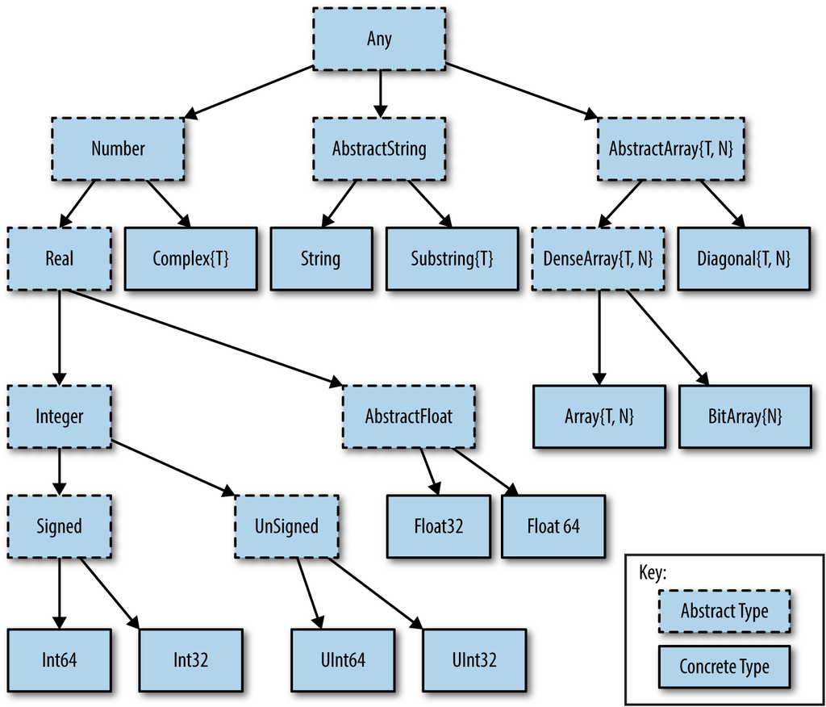

The type hierarchy - Image from https://thautwarm.github.io/

This consists of abstract and concrete types. You can only instantiate a variable of a concrete type, but the abstract types are useful to specify groups of types that would behave similarly, e.g., `Float64` and `Int64` could both the added and multiplied. This is true for all the `Number` types, be they `Real` or `Complex`. We could specify allowed groups of types, via the `<:` operator, or specific types, via `::`, e.g.

```julia
function f(x::T) where T <: Number
    #do something
end
```

Here, Julia will allow us to call f(x) with any sub-type of the `Number` abstract type, such as `Float64`, `Int32` or `ComplexF64`. Calling f(x) with a `String` type will give an error, rather than try to compile a specialised version of `f()`.

We can also use this to have alternative versions of a function for different types of inputs, via multiple dispatch:

```julia
function addthem(a::T, b::S) where {T<:Number, S<:Number}
    return a + b
end

function addthem(a::T, b::T) where T<:AbstractString
    return a * b
end

addthem(1, 2)
#3

addthem(2, 2.0)
#4.0

addthem("One", "Two")
#OneTwo
```

**Note**

Note that in the first function we use T and S, both sub-types of `Number`. If both variables where `T<:Number`, then calling the function with an integer and a floating point value - the second example - would have given an error, as the two variables are not of the same type.

We also used `AbstractString` for the second function, so any type that acts like a `String` should work, as long as they have the `*` operator defined.

### Structs

Structs are use-defined complex types that can contain multiple fields. They are defined using the `struct` keyword:

```julia
struct PersonData
    name::String
    address::String
    ID::Int64
end

customers = PersonData[] # empty array of PersonData structs
# PersonData[]

typeof(customers)
# Vector{PersonData} (alias for Array{PersonData, 1})

bob = PersonData("Robert Smith", "2 Cypress Lane", 123456) # create a variable of type PersonData by calling the constructor
# PersonData("Robert Smith", "2 Cypress Lane", 123456)

push!(customers, bob) # push an entry into the array - will increase the length by one
# 1-element Vector{PersonData}:
#  PersonData("Robert Smith", "2 Cypress Lane", 123456)

customers[1]
# PersonData("Robert Smith", "2 Cypress Lane", 123456)

bob.name # access the values via the field names
# "Robert Smith"

customers[1].name
# "Robert Smith"
```

By default, a `struct` is immutable, meaning it cannot be changed once created:

```julia
bob.name = "Joe Bloggs"
# ERROR: setfield!: immutable struct of type PersonData cannot be changed
# Stacktrace:
#  [1] setproperty!(x::PersonData, f::Symbol, v::String)
#    @ Base .\Base.jl:39
#  [2] top-level scope
#    @ REPL[31]:1
```

To make a `struct` mutable, simply add the keyword `mutable` to the definition.

```julia
mutable struct PersonData2
    name::String
    address::String
    ID::Int64
end

bob = PersonData2("Robert Smith", "2 Cypress Lane", 123456)
# PersonData2("Robert Smith", "2 Cypress Lane", 123456)

bob.name
# "Robert Smith"

bob.name = "Joe Bloggs"
# "Joe Bloggs"

bob
# PersonData2("Joe Bloggs", "2 Cypress Lane", 123456)
```

The `struct` is immutable by default to allow additional compiler optimisations. Mutable structs will therefore have worse performance, but more flexibility.

#### Constructors

Julia automatically creates a *constructor* for each struct you define. This is a function that takes the values of the fields, creates a new structure in memory and assigns the specified values to the fields.

You can also create additional constructors. There are two types:

- Outer constructors and
- Inner constructors

The default constructor is an outer constructor. You can also specify additional outer constructors that e.g., have default values for some fields, or calculate some values from others:

```julia
struct PersonData
    name::String
    address::String
    ID::Int64
end

bob = PersonData("Robert Smith", "2 Cypress Lane", 123456)
# PersonData("Robert Smith", "2 Cypress Lane", 123456)

function PersonData(name, ID)
    # Call the default constructor to do the allocations and assignments
    PersonData(name, "No known address", ID)
end
# PersonData

sally = PersonData("Sally Jones", 123)
# PersonData("Sally Jones", "No known address", 123)

sally.address
# "No known address"

tom = PersonData("Tom Jones", "Las Vegas", 34556) # The default is still available
# PersonData("Tom Jones", "Las Vegas", 34556
```

Inner constructors are defined as part of the `struct` definition and are used to validate the entries for the struct before creating the instance.

```julia
struct OnlyNegatives
    val::Float64
    OnlyNegatives(val) = val > 0 ? error("Non-negative value!") : new(val)
end

OnlyNegatives(-1)
# OnlyNegatives(-1.0)

OnlyNegatives(1)
# ERROR: Non-negative value!
# Stacktrace:
#  [1] error(s::String)
#    @ Base .\error.jl:35
#  [2] OnlyNegatives(val::Int64)
#    @ Main .\REPL[7]:3
#  [3] top-level scope
#    @ REPL[9]:1
```

Inner constructors have access to a special local function, `new()`, which acts like the default outer constructor would.

**Important**

If you define an inner constructor, **NO** default constructors are created. You need to handle all cases via your inner constructors.

## Loops

Julia provides two types of loops:

1. `for` loops for iterating over an iterable construct, like a range or array with a known length
2. `while` loops for iterating until a logical criterium is met, with an initially unknown number of iterations

```julia
a = zeros(5)
# 5-element Vector{Float64}:
#  0.0
#  0.0
#  0.0
#  0.0
#  0.0

for i in 1:length(a)
    a[i] = 2*i^2
end

a
# 5-element Vector{Float64}:
#   2.0
#   8.0
#  18.0
#  32.0
#  50.0

while a[i] <= 10
    println(i, "\t", a[i])
    i += 1
end
# 1       2.0
# 2       8.0
```

In a `while` loop, it is critical to manually implement a step (`i += 1` in the example), or the loop will execute indefinitely!

## Logic and Flow Control

At some point in your code, you will want to execute different instructions depending on some criteria. The most basic form of flow control is the `if` statement:

```julia
if a < 0
    println("Negative")
elseif a == 0
    println("Zero")
else
    println("Positive")
end
```

The `elseif` and `else` blocks are optional. You can have multiple `elseif` blocks with different criteria. You can also nest `if` statements. The `end` statement is a requirement. Unlike many other languages, there is no `then` keyword (`if`…`then`…`else`…`end`).

Julia also offers a short-cut alternative for for simple `if` statements. The following two statements will both print the value `Negative` if `a < 0`.

```julia
a < 0 && println("Negative")
a >= 0 || println("Negative")
```

This looks a little arcane. It works as follows:

The `&&` operator is a logical `and`. For an `and` statement to be true, both criteria must be true, so if the first statement (before the `&&`) is false, Julia won’t bother to evaluate the second statement (after the `&&`), since the whole cannot be true. This is called *short-circuiting evaluation*. This means the `println()` is only executed if `a` is indeed less than zero.

The `||` operator is a logical `or`. For an `or` statement to be true, either of the two criteria must be true, so if the first statement is true, there is no need need to also evaluate the second - the whole is already true. The `println()` will therefore not be executed if `a` is larger than or equal to zero.

**Tip**

To help you remember how *short-circuiting evaluations* work, try this:

`a < 0 && println("Negative")` reads as `a < 0` AND then `println()`

`a >= 0 || println("Negative")` reads as `a >= 0` OR else `println()`

You may very well choose to stick to more readily understandable `if` statements in your code, but these *short-circuit* notations are commonly used and you will encounter them often in other people’s code

Finally, when you are only assigning values to a variable based on some criterium, there is the so-called *ternary operator*:

```julia
a
# -1

b = a > 0 ? "Positive" : "Not positive"
# "Not positive"
```

These can be nested as well:

```julia
b = a > 0 ? "Positive" : (a == 0 ? "Zero" : "Negative")
# "Negative"
```

The parentheses around the final statement are optional, but significantly improves readability.

## Functions

Functions are the core of any Julia program. Inputs are passed as parameters and any number and type of values can be returned as a tuple. You can also modify the values of array parameters passed to the function. In this case, the function is called *mutating* and it is accepted practise in Julia to end the function name with an exclamation mark (or a bang, if you are American), to indicate that the function mutates one or more parameters. Typically, it would be the first parameter that is mutated.

**Note**

Most people use the terms *parameter* and *argument* interchangeably as they refer to functions. If you want to be strictly formal, then a function is defined to accept *parameters* and you pass specific *argument* values when you call the function. Here, we won’t be formal - feel free to use either term.

There are four ways to declare a function:

1. Full declaration

```julia
function myfunc(a, b)
    return a + b
end
```

The keyword `return` is optional, but it significantly improves readability. In the absence of a `return` statement, Julia will return the last calculated result. You can also have multiple `return` statements in, e.g., an `if` block. When a `return` is executed (evaluated in Julia parlance), the function will return the specified value and exit.

2. Short-cut for single-line functions

```julia
myfunc(a, b) = a + b
```

3. Anonymous functions, typically used when passing a single-use function to a higher-level function (a function that takes another function as input)

```julia
mysum = sum(x -> x^2 + √x, somearray)
```

Here Julia will apply the function `x -> x^2 + √x` to each entry in the array `somearray` and then add up the results.

You technically can pass only one parameter to an anonymous function, but since that parameter can be a tuple (and tuples can contain scalars. arrays or even other tuples), there is practically no limit to the number of parameters passed, e.g.

```julia
f = (x, y) -> 2x/y^2
```

Here we also assign the result of the function definition to a variable, `f`, which means we can later call `f(x, y)`. There is really no reason to do this. Rather use the short-cut function definition above.

4. Do blocks (similar to anonymous functions, but for multi-line functions)

```julia
open("myfile.txt", "w") do io
    write(io, "Hello world!")
end
```

Here, there are a few things to pay attention to:

- We are calling the higher-level function `open()`, which takes another function as its first parameter. The `do` block **ALWAYS** passes the specified (anonymous) function to the first parameter of the calling function. The nominal syntax for `open()` is `open(f::Function, args...; kwargs...)`. The function, `f` is specified by the `do` block.
- We pass the parameter `io` to the function be specifying `io` next to the keyword `do`. This is similar to the `x -> ...` in an anonymous function, here we effectively have `io -> ...`

### Passing Values to Functions and Returning Results

In all of the examples so far, we have passed values to the functions. These values are called *parameters* or *arguments*[^3] and there are two types of parameters in Julia: positional parameters and keyword arguments.

#### Positional parameters

Positional parameters are parameters where Julia knows which local (to the function) variable to assign the value to, based on the parameter’s position in the list of arguments. If we have a function `f(x, y)`, and we call it with `f(1, 2)`, Julia will assign the value of 1 to `x` and 2 to `y`.

Positional parameters can have default values: `f(x, y=2)`. We can now either call the function with `f(2, 4)`, in which case `x` will be assigned a value of 2 and `y` a value of 4, or we can omit the value for `y` and call `f(2)`, in which was `x` will be assigned a value of 2 and `y` will use its default value, also 2.

Multiple parameters can have default values, e.g. `f(x, y=2, z = 3)`. If we now call `f(2)`, `y` and `z` use their default values. What happens when we call `f(2, 10)`?

```julia
function f(x, y=2, z=4)
    println(x)
    println(y)
    println(z)
end

f(2)
# 2
# 2
# 4

f(2, 10)
# 2
# 10
# 4
```

We see that the second value is passed to `y`, since it is the second positional parameter. Positional values are always assigned left to right, then default values are used for what is left. So how would we pass values for `x` and `z` and have `y` use its default value? The answer is keyword arguments.

#### Keyword arguments

Keyword arguments (a.k.a. keyword parameters, a.k.a. *kwargs*[^4]) are identified by name when passing values to a function. To define them, we first list the positional parameters, then a semi-colon, then the keyword arguments. Keyword arguments **must** all have default values assigned to them.

```julia
function f(x; y=2, z=4)
    println(x)
    println(y)
    println(z)
end

f(2)
# 2
# 2
# 4
```

So, as expected, `y` and `z` are using their default values. We can now decide to override the defaults for `y`, `z` or both:

```julia
f(2, z=3)
# 2
# 2
# 3

f(2, y=5, z=10)
# 2
# 5
# 10
```

Since `x` is a positional parameters, a value must always be passed for it, or we get an error:

```julia
f(y=5, z=10)
# ERROR: MethodError: no method matching f(; y::Int64, z::Int64)

# Closest candidates are:
#   f(::Any; y, z)
#    @ Main d:\JuliaCode\Julia4ER\Julia for Engineering Research\scrathpad.jl:42
```

**Note**

It is common to find that positional and keyword arguments are separated with a semi-colon at the point where the function is called, e.g. `f(2; y=3, z=5)`. This is just done to emphasise that the parameters after the semi-colon are kwargs, but it is not required. A comma will do just fine.

#### Returning Results

As mentioned above, to return values from a function, there are two preferred options:

- Use the keyword `return`
- Mutate (modify) an array passed as parameter to the function

Functions in Julia will always return a value. Either there is an explicit `return` statement, or the last calculated value is automatically returned. It is good practise to always explicitly return a value. If your function returns nothing, then use `return nothing` to prevent an unexpected and unintended value from being returned.

You can have multiple `return` statements, but the first one to execute will terminate the function and return to the line after the call to the function.

```julia
function isnotnegative(x)
    if x >= 0
        return true
    else
        return false
    end
end
```

or more concisely

```julia
function isnotnegative(x)
    return x >= 0
end
```

This is more understandable than the equivalent:

```julia
function isnotnegative()
    x >= 0
end
```

Julia uses *pass-by-sharing* for parameters passed to functions. If you don’t know what that means, you are in good [company](https://discourse.julialang.org/t/i-thought-i-understood-pass-by-sharing-in-julia-until-i-found-this/46897/8).

The practical implications however are fairly simply to understand. Parameters are immutable - you cannot modify them:

```julia
function trychangeing(x)
    println("Passed value: $x")
    x = 10
    println("Local value: $x")
end

x = -1
trychangeing(x)
# Passed value: -1
# Local value: 10

println("Value at call site: $x")
# Value at call site: -1

a = [1]
trychangeing(a)
# Passed value: [1]
# Local value: 10

println("Value at call site: $a")
# Value at call site: [1]
```

What happens is that Julia creates a new, local variable in the scope of the function, and assigns it the value of the argument that was passed. You can change the values of the parameters, but that does not affect the variables that were passed to the function - `x` and `a` in the examples above.

How do you then mutate an argument? You cannot change scalar values at all. Neither can you change an array. But the value of an array is just a pointer to some data that it contains, and you *can* change *that* data:

```julia
function canchange!(x)
    println("Passed value: $x")
    x[1] = -10
    println("Local value: $x")
end

a = [1, 2, 3]
canchange!(a)
# Passed value: [1, 2, 3]
# Local value: [-10, 2, 3]

println(a)
[-10, 2, 3]
```

**Note**

Note the addition of the exclamation mark (or “bang”, for our American friends) to the name of the function. This is not a Julia requirement, just good manners. We inform the user of the code that one or parameter will be mutated. By convention, this will be the first parameter.

A function returns only one value. What then if you need to return more than one result? Simply return them as a tuple and unpack them at the call site:

```julia
function sqr_two(a, b)
    return a^2, b^2 # The parentheses around the tuple are optional
end

a2, b2 = sqr_two(2, 3) # Unpack the returned tuple into the two variables, a2 and b2
println("a2 = $a2 and b2 = $b2."
# a2 = 4 and b2 = 9.
```

#### Slurping and Splatting - Variable number of positional arguments

Julia uses the `...` operator to *slurp* and *splat* values. Slurping means combining multiple scalar values into an array or tuple (slurping them up) and splatting means breaking an array or tuple into a number of scalar values. While this is sometimes used in other places, the most common application is to allow a variable number of parameters to be passed to a function.

```julia
function confused(a, b, c...)
    println("a is $a")
    println("b is $b")
    println("c is $c")
end

confused(1, 2, 3, 4, 5)
# a is 1
# b is 2
# c is (3, 4, 5)
```

Splatting allows an array to be passed to a function that expects a number of scalars:

```julia
function confused2(a, b, c)
    println("a is $a")
    println("b is $b")
    println("c is $c")
end

x = [1, 2, 3]
confused2(x...)
# a is 1
# b is 2
# c is 3

x = [1, 2, 3, 4]
confused2(x...)
# ERROR: MethodError: no method matching confused2(::Int64, ::Int64, ::Int64, ::Int64)

# Closest candidates are:
#   confused2(::Any, ::Any, ::Any)
# ...
```

The last example results in an error, as there is no version of the function that accepts four parameters.

## Type Stability and Fast Code

Being able to change the type of a variable can be useful, but it does also open the door to something that can cause slowdown in your code: **type instability**. This is when the type of x changes during the execution of your code, making many of the optimisations Julia could do, impossible. Instead, additional code is required to handle the type changes. Keep a look-out for something like this:

```julia
function myfunc(n)
    sum = 0
    for i in 1:n
        sum += 1.5
    end
    return sum
end
```

At first glance, there is nothing strange about this code. If you take a closer look however, you will see that `sum` is created as an integer via `sum = 0`, but then we assign floating-point values to it.

Julia has a lot of code analyses tools. One of which is `@code_warntype`:

```julia
@code_warntype myfunc(5)

MethodInstance for myfunc(::Int64)
  from myfunc(n) in Main at REPL[20]:1
Arguments
  #self#::Core.Const(myfunc)
  n::Int64
Locals
  @_3::Union{Nothing, Tuple{Int64, Int64}}
  sum::Union{Float64, Int64}
  i::Int64
Body::Union{Float64, Int64}
1 ─       (sum = 0)
│   %2  = (1:n)::Core.PartialStruct(UnitRange{Int64}, Any[Core.Const(1), Int64])
│         (@_3 = Base.iterate(%2))
│   %4  = (@_3 === nothing)::Bool
│   %5  = Base.not_int(%4)::Bool
└──       goto #4 if not %5
2 ┄ %7  = @_3::Tuple{Int64, Int64}
│         (i = Core.getfield(%7, 1))
│   %9  = Core.getfield(%7, 2)::Int64
│         (sum = sum + 1.5)
│         (@_3 = Base.iterate(%2, %9))
│   %12 = (@_3 === nothing)::Bool
│   %13 = Base.not_int(%12)::Bool
└──       goto #4 if not %13
3 ─       goto #2
4 ┄       return sum
```

Like when we looked at the LLVM code generated for a function, this may seem intimidating, but the important bits are these:

```julia
sum::Union{Float64, Int64}
```

and

```julia
Body::Union{Float64, Int64}
```

**Note**

In the REPL these are helpfully printed in red to draw your attention.

Julia indicates that the variable `sum` is not type stable. It is assigned both `Int64` and `Float64`values. This limits the amount of optimisation that is allowed and ends up in slower code.

To learn more about type stability and many other useful tips to help you write faster code, refer to the [Performance Tips](https://docs.julialang.org/en/v1/manual/performance-tips/) section in the manual.

The main things to consider, if you want fast code are:

1. The fastest code is code that you don’t need to execute. **Better algorithms always trump more optimised code**
2. Avoid type instability in your code.
3. Avoid unnecessary memory allocation by re-using arrays where possible.

Once you have these issues under control, learning to properly benchmark your code (using BenchmarkTools.jl) will allow you to fine tune the performance of your code. Writing fast code is mostly about *not writing slow code*.

Back to top

## Footnotes

[^1]: An Nvidia Tesla A100 costs about US$7400 in mid-2023
[^2]: A pointer is just a memory address - computer guys like their jargon.
[^3]: See the previous comment on this - the terms are often used interchangeably
[^4]: In the spirit of computer science (and technical fields in general) the least understandable option - kwargs - is also the most used one. Go figure.